# Air Quality in Bangladesh: A Spatiotemporal Analysis of 27 Cities, 2022-2025

Istiaque Ahamed Nabed

27 July 2026

# 1 Introduction

Air pollution is one of the largest environmental health risks in Bangladesh. This report analyses an hourly air quality dataset covering 27 cities from August 2022 to November 2025.

The analysis answers five questions:

1. How polluted is the air, and how does this compare to WHO guidelines?
2. Which cities are worst affected?
3. How does pollution change through the day and through the year?
4. Is air quality getting better or worse over time?
5. How do the different pollutants relate to each other?

All code is included so the analysis can be reproduced from the raw file.

# 2 Setup

## 2.1 Packages

```r
library(tidyverse)   # data handling and plotting
library(lubridate)   # date and time handling
library(scales)      # axis formatting
library(viridis)     # colour scales
library(patchwork)   # combining plots
library(corrplot)    # correlation matrix plot
library(trend)       # Mann-Kendall and Sen's slope
library(knitr)       # tables
library(maps)        # country outline for the map
library(ggrepel)     # non-overlapping point labels

theme_set(theme_minimal(base_size = 12))
```

## 2.2 Plot theme

A single theme is defined here so every figure looks consistent.

```r
theme_report <- theme_minimal(base_size = 12) +
  theme(
    plot.title    = element_text(face = "bold", size = 13),
    plot.subtitle = element_text(colour = "grey35", size = 10),
    plot.caption  = element_text(colour = "grey45", size = 8, hjust = 0),
    panel.grid.minor = element_blank(),
    strip.text    = element_text(face = "bold", size = 9),
    legend.position = "bottom"
  )

theme_set(theme_report)

pal_main <- "#2C7A7B"   # teal
pal_warn <- "#C05621"   # orange
pal_bad  <- "#9B2C2C"   # dark red
```

# 3 Data

## 3.1 Import

```r
# Adjust this path if the file sits somewhere else
raw <- read_csv("AQI_Bangladesh.csv", show_col_types = FALSE)

dim(raw)
```

```
## [1] 782784     16
```

```r
names(raw)
```

```
##  [1] "city_id"          "city_name"        "lat"              "lon"
##  [5] "Year"             "Month"            "Date"             "Hour"
##  [9] "pm10"             "pm2_5"            "carbon_monoxide"  "carbon_dioxide"
## [13] "nitrogen_dioxide" "sulphur_dioxide"  "ozone"            "aqi"
```

## 3.2 Cleaning

Five things are done here.

1. `Hour` is stored as text like `"14:00"`, so the number is extracted.
2. A proper datetime column is built from Year, Month, Date and Hour.
3. `carbon_dioxide` is dropped because roughly two thirds of it is missing.
4. Small negative values in `nitrogen_dioxide` and `ozone` come from instrument rounding near zero. They are set to zero rather than removed.
5. A season column is added using the standard Bangladesh seasonal calendar.

```r
aq <- raw %>%
  mutate(
    hour_num = as.integer(str_remove(Hour, ":.*")),
    datetime = make_datetime(Year, Month, Date, hour_num),
    date     = as_date(datetime),
    month_name = month(datetime, label = TRUE, abbr = TRUE),
    weekday    = wday(datetime, label = TRUE, abbr = TRUE, week_start = 7),
    season = case_when(
      Month %in% c(12, 1, 2) ~ "Winter",
      Month %in% c(3, 4, 5)  ~ "Pre-monsoon",
      Month %in% c(6, 7, 8, 9) ~ "Monsoon",
      Month %in% c(10, 11)   ~ "Post-monsoon"
    ),
    season = factor(season,
                    levels = c("Winter", "Pre-monsoon", "Monsoon", "Post-monsoon")),
    # clip small negatives to zero
    nitrogen_dioxide = pmax(nitrogen_dioxide, 0),
    ozone            = pmax(ozone, 0)
  ) %>%
  select(-carbon_dioxide, -Hour) %>%
  rename(
    city = city_name,
    pm25 = pm2_5,
    co   = carbon_monoxide,
    no2  = nitrogen_dioxide,
    so2  = sulphur_dioxide,
    o3   = ozone
  )

glimpse(aq)
```

```
## Rows: 782,784
## Columns: 20
## $ city_id    <dbl> 1185283, 1185283, 1185283, 1185283, 1185283, 1185283, 11852…
## $ city       <chr> "Badarganj", "Badarganj", "Badarganj", "Badarganj", "Badarg…
## $ lat        <dbl> 25.67419, 25.67419, 25.67419, 25.67419, 25.67419, 25.67419,…
## $ lon        <dbl> 89.05377, 89.05377, 89.05377, 89.05377, 89.05377, 89.05377,…
## $ Year       <dbl> 2022, 2022, 2022, 2022, 2022, 2022, 2022, 2022, 2022, 2022,…
## $ Month      <dbl> 8, 8, 8, 8, 8, 8, 8, 8, 8, 8, 8, 8, 8, 8, 8, 8, 8, 8, 8, 8,…
## $ Date       <dbl> 4, 4, 4, 4, 4, 4, 4, 4, 4, 4, 4, 4, 4, 4, 4, 4, 4, 4, 4, 4,…
## $ pm10       <dbl> 34.8, 34.6, 29.2, 27.2, 20.7, 18.3, 18.9, 22.0, 21.9, 22.4,…
## $ pm25       <dbl> 24.3, 24.1, 20.4, 18.9, 14.4, 12.8, 13.2, 15.4, 15.3, 15.7,…
## $ co         <dbl> 245, 238, 227, 213, 203, 193, 183, 180, 179, 181, 179, 178,…
## $ no2        <dbl> 8.4, 8.1, 7.5, 6.8, 6.2, 5.4, 4.8, 4.3, 4.1, 4.1, 4.1, 4.2,…
## $ so2        <dbl> 1.3, 1.7, 2.3, 2.8, 2.7, 2.3, 1.8, 1.5, 1.1, 0.8, 0.7, 0.6,…
## $ o3         <dbl> 48, 51, 56, 62, 66, 69, 74, 79, 84, 90, 93, 94, 86, 76, 62,…
## $ aqi        <dbl> NA, NA, NA, NA, NA, NA, NA, NA, NA, NA, NA, NA, NA, NA, NA,…
## $ hour_num   <int> 0, 1, 2, 3, 4, 5, 6, 7, 8, 9, 10, 11, 12, 13, 14, 15, 16, 1…
## $ datetime   <dttm> 2022-08-04 00:00:00, 2022-08-04 01:00:00, 2022-08-04 02:00…
## $ date       <date> 2022-08-04, 2022-08-04, 2022-08-04, 2022-08-04, 2022-08-04…
## $ month_name <ord> Aug, Aug, Aug, Aug, Aug, Aug, Aug, Aug, Aug, Aug, Aug, Aug,…
## $ weekday    <ord> Thu, Thu, Thu, Thu, Thu, Thu, Thu, Thu, Thu, Thu, Thu, Thu,…
## $ season     <fct> Monsoon, Monsoon, Monsoon, Monsoon, Monsoon, Monsoon, Monso…
```

## 3.3 Coverage check

Before analysing anything, it is worth confirming the panel is complete.

```r
coverage <- aq %>%
  group_by(city) %>%
  summarise(
    n_hours   = n(),
    first_obs = min(date),
    last_obs  = max(date),
    missing_aqi = sum(is.na(aqi)),
    .groups = "drop"
  )

kable(head(coverage, 10), caption = "Data coverage by city (first 10 shown)")
```

Data coverage by city (first 10 shown)

| city | n_hours | first_obs | last_obs | missing_aqi |
| --- | --- | --- | --- | --- |
| Badarganj | 28992 | 2022-08-04 | 2025-11-23 | 24 |
| Bajitpur | 28992 | 2022-08-04 | 2025-11-23 | 24 |
| Bandarban | 28992 | 2022-08-04 | 2025-11-23 | 24 |
| Baniachang | 28992 | 2022-08-04 | 2025-11-23 | 24 |
| Barisal | 28992 | 2022-08-04 | 2025-11-23 | 24 |
| Bera | 28992 | 2022-08-04 | 2025-11-23 | 24 |
| Bhairab Bazar | 28992 | 2022-08-04 | 2025-11-23 | 24 |
| Bhandaria | 28992 | 2022-08-04 | 2025-11-23 | 24 |
| Bhatpara Abhaynagar | 28992 | 2022-08-04 | 2025-11-23 | 24 |
| Bheramara | 28992 | 2022-08-04 | 2025-11-23 | 24 |

```r
cat("Cities:", n_distinct(aq$city), "\n")
```

```
## Cities: 27
```

```r
cat("Period:", as.character(min(aq$date)), "to", as.character(max(aq$date)), "\n")
```

```
## Period: 2022-08-04 to 2025-11-23
```

```r
cat("Total records:", format(nrow(aq), big.mark = ","), "\n")
```

```
## Total records: 782,784
```

The panel is balanced: every city has the same number of hourly records over the same period. Note that 2022 starts in August and 2025 ends in November, so those two years are incomplete. Any year-on-year comparison below uses only 2023 and 2024, which are full years.

## 3.4 Missing data

```r
aq %>%
  summarise(across(c(pm10, pm25, co, no2, so2, o3, aqi),
                   ~ round(mean(is.na(.x)) * 100, 3))) %>%
  pivot_longer(everything(), names_to = "variable", values_to = "missing_pct") %>%
  kable(caption = "Percentage of missing values by pollutant")
```

Percentage of missing values by pollutant

| variable | missing_pct |
| --- | --- |
| pm10 | 0.000 |
| pm25 | 0.000 |
| co | 0.000 |
| no2 | 0.000 |
| so2 | 0.000 |
| o3 | 0.000 |
| aqi | 0.083 |

Missingness is negligible, so no imputation is needed.

# 4 Descriptive statistics

## 4.1 Overall summary

```r
pollutants <- c("pm25", "pm10", "no2", "so2", "o3", "co", "aqi")

desc <- aq %>%
  select(all_of(pollutants)) %>%
  pivot_longer(everything(), names_to = "pollutant", values_to = "value") %>%
  group_by(pollutant) %>%
  summarise(
    n      = sum(!is.na(value)),
    mean   = mean(value, na.rm = TRUE),
    sd     = sd(value, na.rm = TRUE),
    min    = min(value, na.rm = TRUE),
    p25    = quantile(value, 0.25, na.rm = TRUE),
    median = median(value, na.rm = TRUE),
    p75    = quantile(value, 0.75, na.rm = TRUE),
    p95    = quantile(value, 0.95, na.rm = TRUE),
    max    = max(value, na.rm = TRUE),
    .groups = "drop"
  ) %>%
  mutate(across(where(is.numeric), ~ round(.x, 1)))

kable(desc, caption = "Summary statistics for all pollutants (hourly values)")
```

Summary statistics for all pollutants (hourly values)

| pollutant | n | mean | sd | min | p25 | median | p75 | p95 | max |
| --- | --- | --- | --- | --- | --- | --- | --- | --- | --- |
| aqi | 782136 | 102.3 | 46.9 | 9.0 | 61.0 | 98.0 | 150.0 | 170.0 | 271.0 |
| co | 782784 | 385.4 | 229.4 | 58.0 | 215.0 | 322.0 | 494.0 | 835.0 | 5084.0 |
| no2 | 782784 | 11.5 | 13.6 | 0.0 | 3.2 | 7.5 | 14.3 | 36.2 | 178.0 |
| o3 | 782784 | 80.1 | 42.0 | 0.0 | 50.0 | 71.0 | 105.0 | 162.0 | 328.0 |
| pm10 | 782784 | 53.8 | 40.4 | 0.2 | 21.8 | 44.5 | 75.9 | 130.4 | 787.9 |
| pm25 | 782784 | 39.6 | 31.0 | 0.1 | 15.8 | 32.0 | 55.1 | 98.5 | 551.3 |
| so2 | 782784 | 6.4 | 6.7 | 0.0 | 2.3 | 4.6 | 8.5 | 17.0 | 172.4 |

The distributions are heavily right-skewed: for most pollutants the maximum is many times the median. This is typical of air quality data and means the mean alone gives a misleading picture.

## 4.2 Distribution of PM2.5

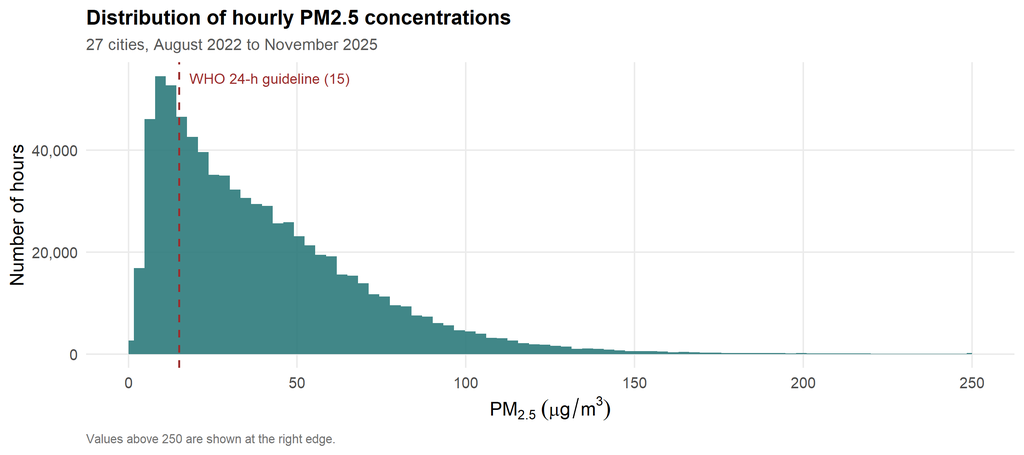

```r
ggplot(aq, aes(x = pm25)) +
  geom_histogram(bins = 80, fill = pal_main, colour = NA, alpha = 0.9) +
  geom_vline(xintercept = 15, linetype = "dashed", colour = pal_bad, linewidth = 0.6) +
  annotate("text", x = 18, y = Inf, vjust = 2, hjust = 0,
           label = "WHO 24-h guideline (15)", colour = pal_bad, size = 3.2) +
  scale_x_continuous(limits = c(0, 250), oob = scales::squish) +
  scale_y_continuous(labels = comma) +
  labs(
    title = "Distribution of hourly PM2.5 concentrations",
    subtitle = "27 cities, August 2022 to November 2025",
    x = expression(PM[2.5]~(mu*g/m^3)),
    y = "Number of hours",
    caption = "Values above 250 are shown at the right edge."
  )
```

# 5 Air Quality Index

## 5.1 AQI categories

The AQI values follow the standard US EPA breakpoints. Assigning each hour to a category makes the burden easier to interpret than a raw average.

```r
aq <- aq %>%
  mutate(
    aqi_cat = cut(
      aqi,
      breaks = c(-Inf, 50, 100, 150, 200, 300, Inf),
      labels = c("Good", "Moderate", "Unhealthy for sensitive groups",
                 "Unhealthy", "Very unhealthy", "Hazardous")
    )
  )

aqi_colours <- c(
  "Good" = "#00A65A",
  "Moderate" = "#F1C40F",
  "Unhealthy for sensitive groups" = "#E67E22",
  "Unhealthy" = "#E74C3C",
  "Very unhealthy" = "#8E44AD",
  "Hazardous" = "#7B241C"
)

aq %>%
  filter(!is.na(aqi_cat)) %>%
  count(aqi_cat) %>%
  mutate(percent = round(n / sum(n) * 100, 1)) %>%
  kable(caption = "Share of hours in each AQI category, all cities pooled")
```

Share of hours in each AQI category, all cities pooled

| aqi_cat | n | percent |
| --- | --- | --- |
| Good | 119031 | 15.2 |
| Moderate | 282799 | 36.2 |
| Unhealthy for sensitive groups | 185120 | 23.7 |
| Unhealthy | 190869 | 24.4 |
| Very unhealthy | 4317 | 0.6 |

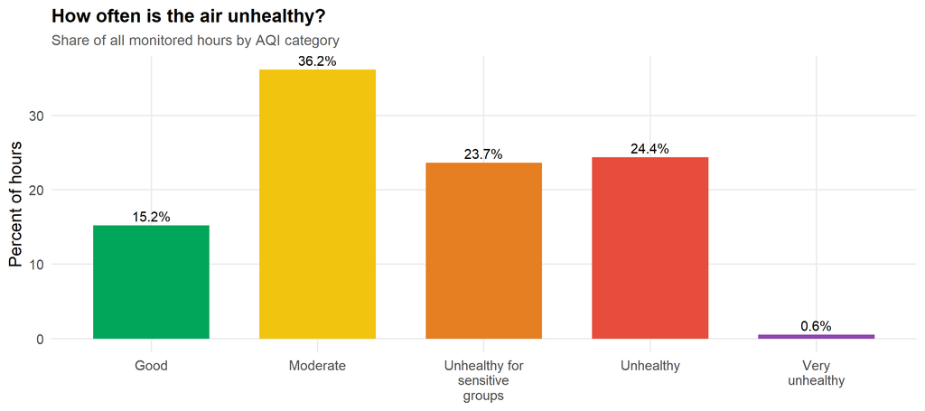

```r
aq %>%
  filter(!is.na(aqi_cat)) %>%
  count(aqi_cat) %>%
  mutate(percent = n / sum(n) * 100) %>%
  ggplot(aes(x = aqi_cat, y = percent, fill = aqi_cat)) +
  geom_col(width = 0.7) +
  geom_text(aes(label = paste0(round(percent, 1), "%")),
            vjust = -0.4, size = 3.4) +
  scale_fill_manual(values = aqi_colours, guide = "none") +
  scale_x_discrete(labels = label_wrap(14)) +
  labs(
    title = "How often is the air unhealthy?",
    subtitle = "Share of all monitored hours by AQI category",
    x = NULL, y = "Percent of hours"
  )
```

## 5.2 AQI category by city

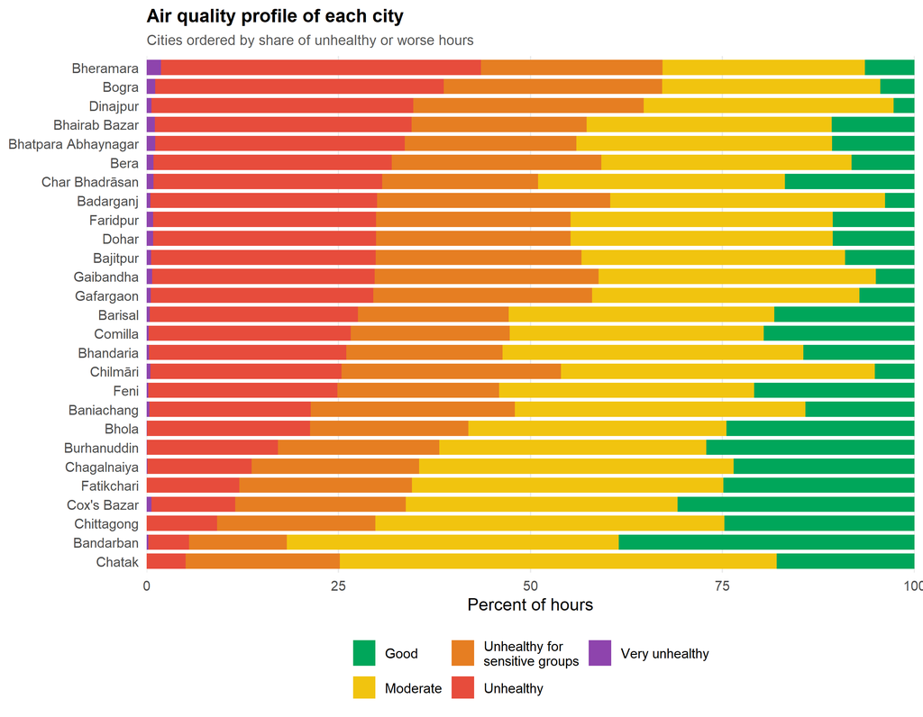

```r
aq %>%
  filter(!is.na(aqi_cat)) %>%
  count(city, aqi_cat) %>%
  group_by(city) %>%
  mutate(percent = n / sum(n) * 100) %>%
  ungroup() %>%
  mutate(city = fct_reorder(city, percent * (aqi_cat %in%
           c("Unhealthy", "Very unhealthy", "Hazardous")), sum)) %>%
  ggplot(aes(x = percent, y = city, fill = aqi_cat)) +
  geom_col(width = 0.8) +
  scale_fill_manual(values = aqi_colours, name = NULL,
                    labels = label_wrap(18)) +
  scale_x_continuous(expand = c(0, 0)) +
  labs(
    title = "Air quality profile of each city",
    subtitle = "Cities ordered by share of unhealthy or worse hours",
    x = "Percent of hours", y = NULL
  ) +
  guides(fill = guide_legend(nrow = 2))
```

# 6 Spatial patterns

## 6.1 City ranking

```r
city_stats <- aq %>%
  group_by(city, lat, lon) %>%
  summarise(
    mean_pm25 = mean(pm25, na.rm = TRUE),
    mean_pm10 = mean(pm10, na.rm = TRUE),
    mean_aqi  = mean(aqi,  na.rm = TRUE),
    p95_pm25  = quantile(pm25, 0.95, na.rm = TRUE),
    .groups = "drop"
  ) %>%
  arrange(desc(mean_pm25))

kable(city_stats %>%
        select(city, mean_pm25, mean_pm10, mean_aqi, p95_pm25) %>%
        mutate(across(where(is.numeric), ~ round(.x, 1))),
      caption = "Cities ranked by mean PM2.5")
```

Cities ranked by mean PM2.5

| city | mean_pm25 | mean_pm10 | mean_aqi | p95_pm25 |
| --- | --- | --- | --- | --- |
| Bheramara | 54.0 | 72.9 | 124.9 | 124.3 |
| Bogra | 51.8 | 69.1 | 122.8 | 118.7 |
| Dinajpur | 49.2 | 65.4 | 120.4 | 111.1 |
| Bera | 46.4 | 63.0 | 114.4 | 107.6 |
| Bhatpara Abhaynagar | 46.3 | 62.6 | 111.8 | 115.0 |
| Bhairab Bazar | 46.1 | 62.0 | 113.3 | 110.6 |
| Badarganj | 45.9 | 61.0 | 115.3 | 103.4 |
| Gaibandha | 45.5 | 61.0 | 114.5 | 102.2 |
| Gafargaon | 44.6 | 59.9 | 112.7 | 101.5 |
| Dohar | 44.0 | 59.6 | 109.7 | 105.0 |
| Faridpur | 44.0 | 59.6 | 109.7 | 105.0 |
| Bajitpur | 43.7 | 58.9 | 111.3 | 101.0 |
| Char Bhadrāsan | 42.4 | 57.7 | 105.3 | 106.4 |
| Chilmāri | 42.3 | 56.7 | 109.4 | 94.5 |
| Bhandaria | 39.8 | 54.5 | 101.1 | 103.4 |
| Barisal | 39.7 | 54.4 | 101.0 | 99.7 |
| Comilla | 38.9 | 52.9 | 100.3 | 97.8 |
| Feni | 37.9 | 51.6 | 98.3 | 95.9 |
| Baniachang | 37.5 | 51.2 | 101.3 | 88.0 |
| Bhola | 35.0 | 48.4 | 93.3 | 89.2 |
| Burhanuddin | 32.3 | 45.2 | 88.7 | 83.8 |
| Chagalnaiya | 30.8 | 42.2 | 87.1 | 77.1 |
| Fatikchari | 29.8 | 41.2 | 85.4 | 74.7 |
| Chittagong | 27.7 | 38.3 | 81.4 | 67.5 |
| Cox’s Bazar | 26.1 | 37.7 | 82.8 | 64.0 |
| Chatak | 25.7 | 35.0 | 79.5 | 60.3 |
| Bandarban | 21.6 | 29.8 | 66.9 | 57.5 |

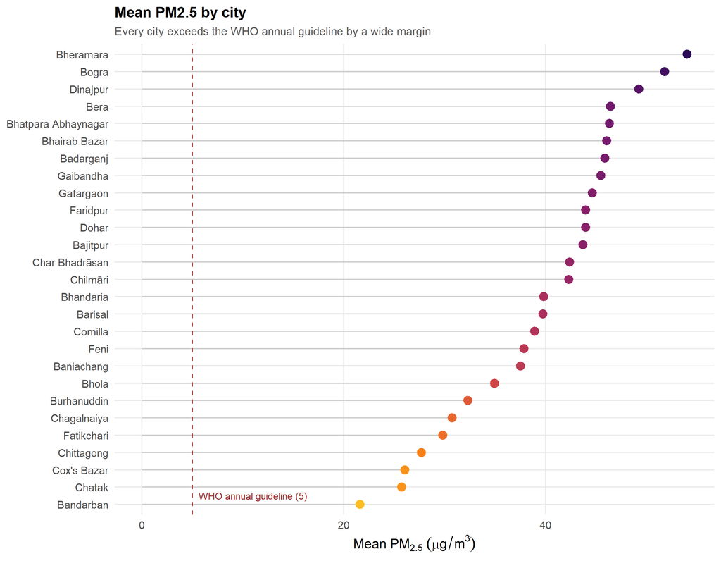

```r
ggplot(city_stats, aes(x = mean_pm25, y = fct_reorder(city, mean_pm25))) +
  geom_segment(aes(xend = 0, yend = fct_reorder(city, mean_pm25)),
               colour = "grey80", linewidth = 0.5) +
  geom_point(aes(colour = mean_pm25), size = 3.2) +
  geom_vline(xintercept = 5, linetype = "dashed", colour = pal_bad) +
  annotate("text", x = 5.6, y = 1.5, hjust = 0, size = 3,
           colour = pal_bad, label = "WHO annual guideline (5)") +
  scale_colour_viridis_c(option = "inferno", direction = -1, guide = "none",
                         begin = 0.15, end = 0.85) +
  labs(
    title = "Mean PM2.5 by city",
    subtitle = "Every city exceeds the WHO annual guideline by a wide margin",
    x = expression(Mean~PM[2.5]~(mu*g/m^3)), y = NULL
  )
```

## 6.2 Map

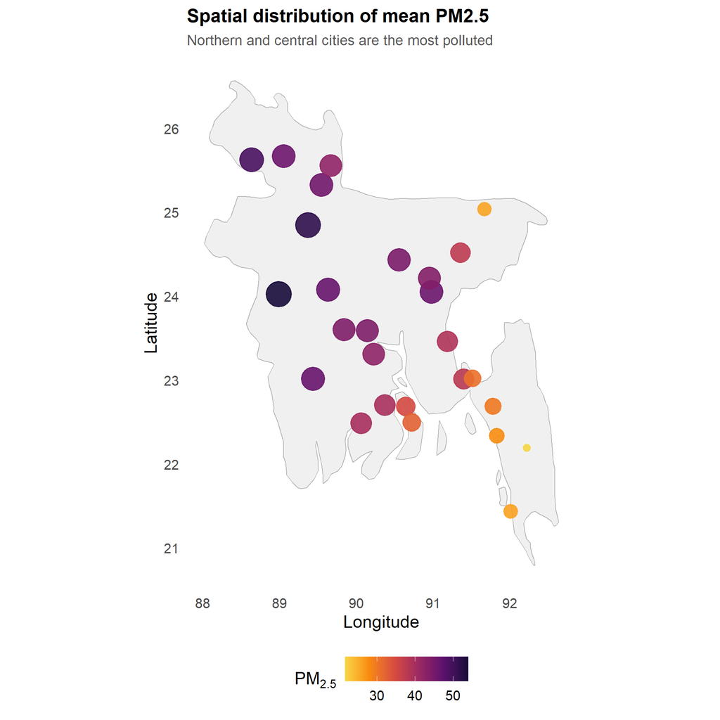

```r
bd <- map_data("world", region = "Bangladesh")

ggplot() +
  geom_polygon(data = bd, aes(long, lat, group = group),
               fill = "grey94", colour = "grey70", linewidth = 0.3) +
  geom_point(data = city_stats,
             aes(lon, lat, colour = mean_pm25, size = mean_pm25),
             alpha = 0.9) +
  scale_colour_viridis_c(option = "inferno", direction = -1,
                         begin = 0.1, end = 0.9,
                         name = expression(PM[2.5])) +
  scale_size_continuous(range = c(2, 8), guide = "none") +
  coord_quickmap() +
  labs(
    title = "Spatial distribution of mean PM2.5",
    subtitle = "Northern and central cities are the most polluted",
    x = "Longitude", y = "Latitude"
  ) +
  theme(panel.grid = element_blank())
```

The map shows a clear north-west to south-east gradient. Cities in the north and centre of the country carry the heaviest load, while coastal and hill cities in the south-east are cleaner.

# 7 Temporal patterns

## 7.1 Daily cycle

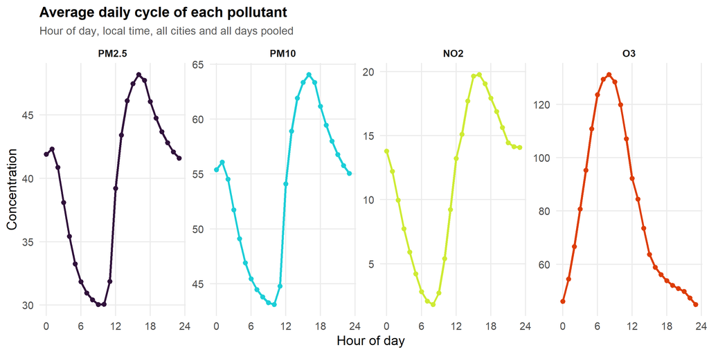

```r
diurnal <- aq %>%
  group_by(hour_num) %>%
  summarise(across(c(pm25, pm10, no2, o3), ~ mean(.x, na.rm = TRUE)),
            .groups = "drop") %>%
  pivot_longer(-hour_num, names_to = "pollutant", values_to = "value") %>%
  mutate(pollutant = factor(pollutant, levels = c("pm25", "pm10", "no2", "o3"),
                            labels = c("PM2.5", "PM10", "NO2", "O3")))

ggplot(diurnal, aes(hour_num, value, colour = pollutant)) +
  geom_line(linewidth = 1) +
  geom_point(size = 1.6) +
  facet_wrap(~ pollutant, scales = "free_y", nrow = 1) +
  scale_colour_viridis_d(option = "turbo", end = 0.85, guide = "none") +
  scale_x_continuous(breaks = seq(0, 24, 6)) +
  labs(
    title = "Average daily cycle of each pollutant",
    subtitle = "Hour of day, local time, all cities and all days pooled",
    x = "Hour of day", y = "Concentration"
  )
```

## 7.2 Seasonal cycle

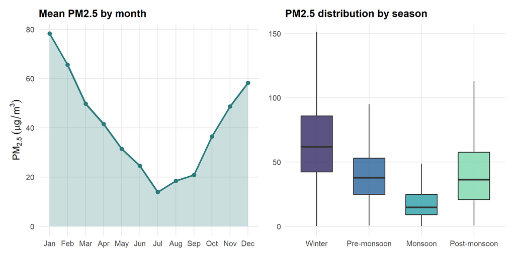

```r
monthly <- aq %>%
  group_by(Month) %>%
  summarise(across(c(pm25, pm10, aqi), ~ mean(.x, na.rm = TRUE)), .groups = "drop") %>%
  mutate(month_lab = month(Month, label = TRUE, abbr = TRUE))

p1 <- ggplot(monthly, aes(month_lab, pm25, group = 1)) +
  geom_area(fill = pal_main, alpha = 0.25) +
  geom_line(colour = pal_main, linewidth = 1.1) +
  geom_point(colour = pal_main, size = 2) +
  labs(title = "Mean PM2.5 by month",
       x = NULL, y = expression(PM[2.5]~(mu*g/m^3)))

p2 <- aq %>%
  ggplot(aes(season, pm25, fill = season)) +
  geom_boxplot(outlier.shape = NA, alpha = 0.85, width = 0.6) +
  coord_cartesian(ylim = c(0, 150)) +
  scale_fill_viridis_d(option = "mako", begin = 0.25, end = 0.85, guide = "none") +
  labs(title = "PM2.5 distribution by season",
       x = NULL, y = NULL)

p1 + p2
```

The seasonal signal is very strong. Pollution peaks in the dry winter months and falls sharply during the monsoon, when rainfall washes particles out of the air and the boundary layer is better ventilated.

```r
aq %>%
  group_by(season) %>%
  summarise(
    mean_pm25 = round(mean(pm25, na.rm = TRUE), 1),
    mean_pm10 = round(mean(pm10, na.rm = TRUE), 1),
    mean_aqi  = round(mean(aqi,  na.rm = TRUE), 1),
    pct_unhealthy = round(mean(aqi > 150, na.rm = TRUE) * 100, 1),
    .groups = "drop"
  ) %>%
  kable(caption = "Seasonal averages and share of unhealthy hours")
```

Seasonal averages and share of unhealthy hours

| season | mean_pm25 | mean_pm10 | mean_aqi | pct_unhealthy |
| --- | --- | --- | --- | --- |
| Winter | 67.4 | 88.2 | 144.5 | 61.4 |
| Pre-monsoon | 40.9 | 58.4 | 113.3 | 22.9 |
| Monsoon | 19.4 | 27.5 | 64.0 | 2.5 |
| Post-monsoon | 42.3 | 56.0 | 109.8 | 25.9 |

## 7.3 Day of week

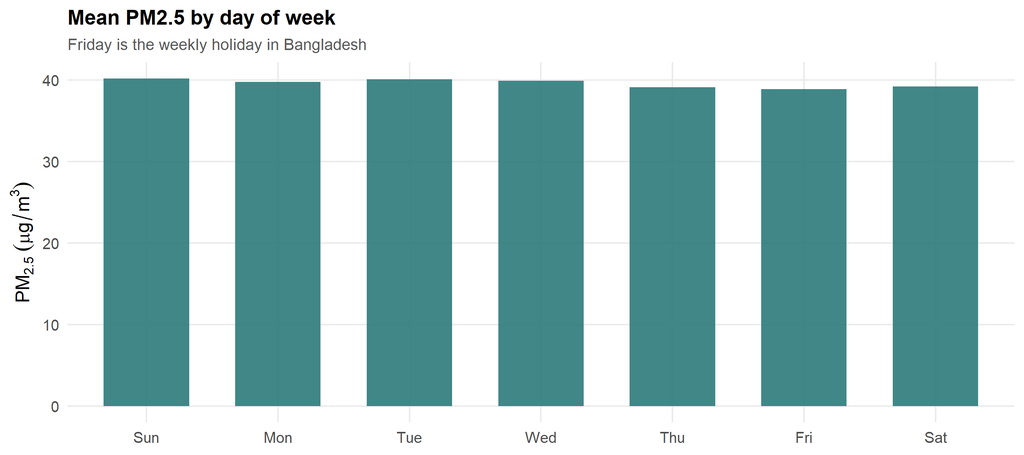

```r
aq %>%
  group_by(weekday) %>%
  summarise(mean_pm25 = mean(pm25, na.rm = TRUE), .groups = "drop") %>%
  ggplot(aes(weekday, mean_pm25)) +
  geom_col(fill = pal_main, width = 0.65, alpha = 0.9) +
  coord_cartesian(ylim = c(0, NA)) +
  labs(
    title = "Mean PM2.5 by day of week",
    subtitle = "Friday is the weekly holiday in Bangladesh",
    x = NULL, y = expression(PM[2.5]~(mu*g/m^3))
  )
```

## 7.4 Full time series

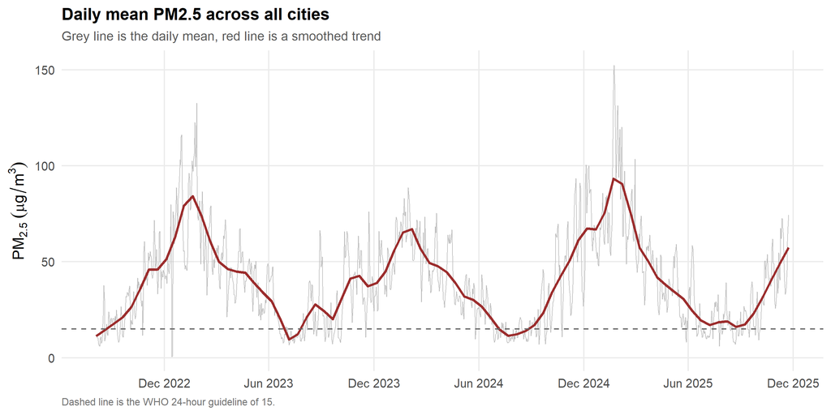

```r
daily_all <- aq %>%
  group_by(date) %>%
  summarise(pm25 = mean(pm25, na.rm = TRUE), .groups = "drop")

ggplot(daily_all, aes(date, pm25)) +
  geom_line(colour = "grey75", linewidth = 0.3) +
  geom_smooth(method = "loess", span = 0.08, se = FALSE,
              colour = pal_bad, linewidth = 1) +
  geom_hline(yintercept = 15, linetype = "dashed", colour = "grey40") +
  scale_x_date(date_breaks = "6 months", date_labels = "%b %Y") +
  labs(
    title = "Daily mean PM2.5 across all cities",
    subtitle = "Grey line is the daily mean, red line is a smoothed trend",
    x = NULL, y = expression(PM[2.5]~(mu*g/m^3)),
    caption = "Dashed line is the WHO 24-hour guideline of 15."
  )
```

# 8 WHO guideline exceedance

The WHO 2021 Global Air Quality Guidelines set both annual and 24-hour limits. Comparing daily means to those limits shows how often the air is unsafe.

```r
who_limits <- tibble(
  pollutant = c("pm25", "pm10", "no2", "so2"),
  limit_24h = c(15, 45, 25, 40),
  label     = c("PM2.5", "PM10", "NO2", "SO2")
)

daily_city <- aq %>%
  group_by(city, date) %>%
  summarise(across(c(pm25, pm10, no2, so2), ~ mean(.x, na.rm = TRUE)),
            .groups = "drop")

exceed <- daily_city %>%
  pivot_longer(c(pm25, pm10, no2, so2),
               names_to = "pollutant", values_to = "value") %>%
  left_join(who_limits, by = "pollutant") %>%
  group_by(label) %>%
  summarise(
    days_total    = n(),
    days_exceed   = sum(value > limit_24h, na.rm = TRUE),
    pct_exceed    = round(days_exceed / days_total * 100, 1),
    .groups = "drop"
  )

kable(exceed, caption = "City-days exceeding the WHO 24-hour guideline")
```

City-days exceeding the WHO 24-hour guideline

| label | days_total | days_exceed | pct_exceed |
| --- | --- | --- | --- |
| NO2 | 32616 | 2291 | 7.0 |
| PM10 | 32616 | 16971 | 52.0 |
| PM2.5 | 32616 | 25754 | 79.0 |
| SO2 | 32616 | 145 | 0.4 |

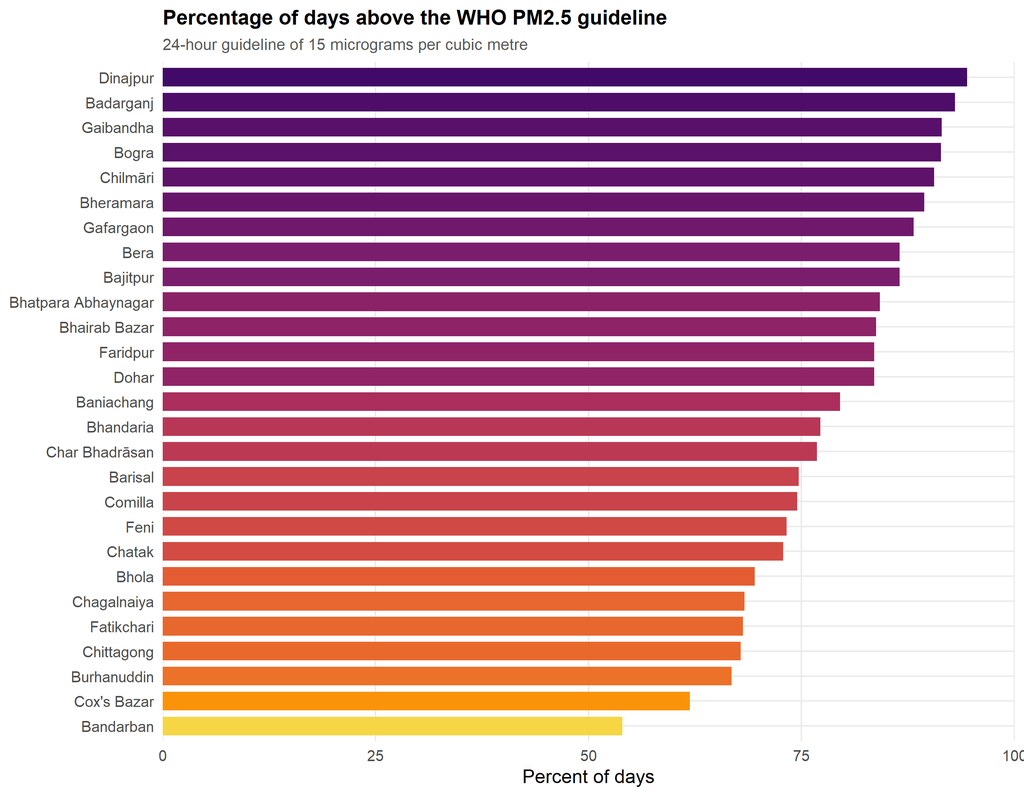

```r
daily_city %>%
  group_by(city) %>%
  summarise(pct = mean(pm25 > 15, na.rm = TRUE) * 100, .groups = "drop") %>%
  ggplot(aes(pct, fct_reorder(city, pct))) +
  geom_col(aes(fill = pct), width = 0.75) +
  scale_fill_viridis_c(option = "inferno", direction = -1,
                       begin = 0.2, end = 0.9, guide = "none") +
  scale_x_continuous(expand = c(0, 0), limits = c(0, 100)) +
  labs(
    title = "Percentage of days above the WHO PM2.5 guideline",
    subtitle = "24-hour guideline of 15 micrograms per cubic metre",
    x = "Percent of days", y = NULL
  )
```

# 9 Relationships between pollutants

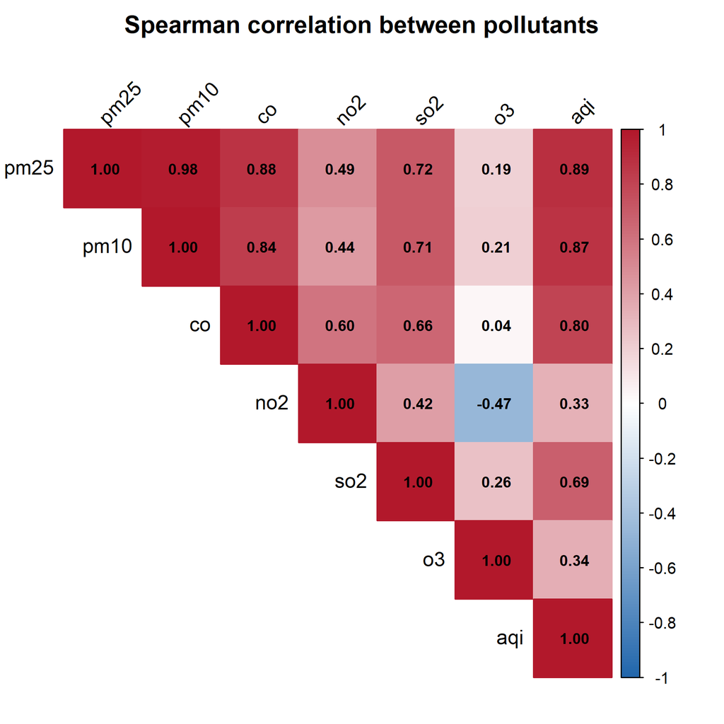

```r
cor_data <- aq %>%
  select(pm25, pm10, co, no2, so2, o3, aqi) %>%
  drop_na()

cor_mat <- cor(cor_data, method = "spearman")

corrplot(cor_mat,
         method = "color",
         type = "upper",
         addCoef.col = "black",
         number.cex = 0.75,
         tl.col = "black",
         tl.srt = 45,
         col = colorRampPalette(c("#2166AC", "white", "#B2182B"))(200),
         mar = c(0, 0, 2, 0),
         title = "Spearman correlation between pollutants")
```

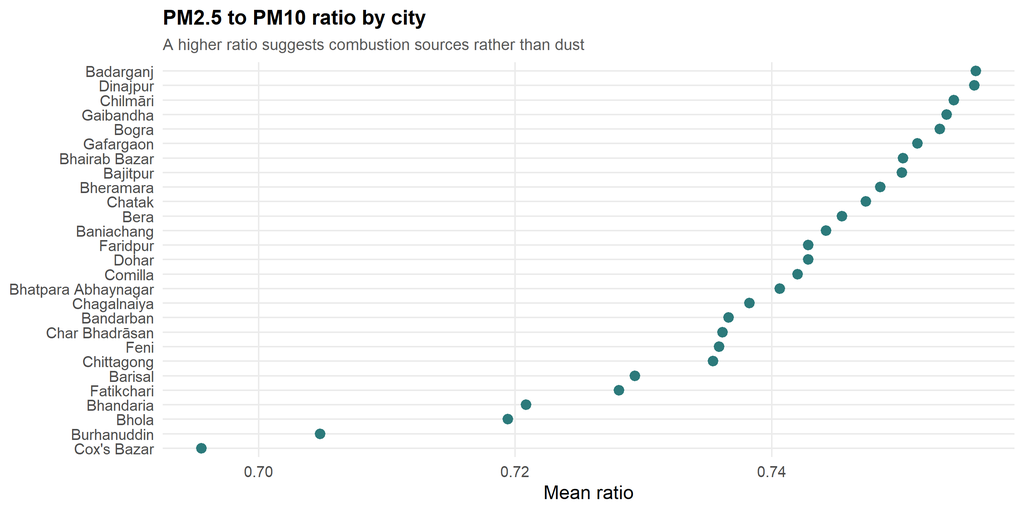

```r
aq %>%
  filter(pm10 > 0) %>%
  mutate(ratio = pm25 / pm10) %>%
  group_by(city) %>%
  summarise(mean_ratio = mean(ratio, na.rm = TRUE), .groups = "drop") %>%
  ggplot(aes(mean_ratio, fct_reorder(city, mean_ratio))) +
  geom_point(colour = pal_main, size = 2.6) +
  labs(
    title = "PM2.5 to PM10 ratio by city",
    subtitle = "A higher ratio suggests combustion sources rather than dust",
    x = "Mean ratio", y = NULL
  )
```

# 10 Trend analysis

A Mann-Kendall test checks whether there is a monotonic trend over time, and Sen’s slope estimates its size. Both are non-parametric, so they do not assume the data are normally distributed. The test is run on monthly means for each city.

```r
monthly_city <- aq %>%
  mutate(ym = floor_date(date, "month")) %>%
  group_by(city, ym) %>%
  summarise(pm25 = mean(pm25, na.rm = TRUE), .groups = "drop") %>%
  arrange(city, ym)

trend_results <- monthly_city %>%
  group_by(city) %>%
  filter(n() >= 24) %>%
  group_modify(~ {
    x  <- .x$pm25
    mk <- mk.test(x)
    ss <- sens.slope(x)
    tibble(
      n_months  = length(x),
      tau       = as.numeric(mk$estimates["tau"]),
      p_value   = mk$p.value,
      slope_per_month = as.numeric(ss$estimates),
      slope_per_year  = as.numeric(ss$estimates) * 12
    )
  }) %>%
  ungroup() %>%
  mutate(
    direction = case_when(
      p_value >= 0.05 ~ "No significant trend",
      slope_per_year > 0 ~ "Increasing",
      TRUE ~ "Decreasing"
    ),
    across(c(tau, slope_per_month, slope_per_year), ~ round(.x, 3)),
    p_value = round(p_value, 4)
  ) %>%
  arrange(slope_per_year)

kable(trend_results, caption = "Mann-Kendall trend test on monthly mean PM2.5")
```

Mann-Kendall trend test on monthly mean PM2.5

| city | n_months | tau | p_value | slope_per_month | slope_per_year | direction |
| --- | --- | --- | --- | --- | --- | --- |
| Cox’s Bazar | 40 | -0.228 | 0.0392 | -0.429 | -5.146 | Decreasing |
| Chittagong | 40 | -0.151 | 0.1728 | -0.250 | -2.996 | No significant trend |
| Bhola | 40 | -0.097 | 0.3822 | -0.235 | -2.821 | No significant trend |
| Comilla | 40 | -0.100 | 0.3696 | -0.233 | -2.792 | No significant trend |
| Bhairab Bazar | 40 | -0.082 | 0.4629 | -0.232 | -2.781 | No significant trend |
| Fatikchari | 40 | -0.123 | 0.2684 | -0.232 | -2.780 | No significant trend |
| Feni | 40 | -0.095 | 0.3950 | -0.220 | -2.642 | No significant trend |
| Burhanuddin | 40 | -0.097 | 0.3822 | -0.209 | -2.504 | No significant trend |
| Baniachang | 40 | -0.077 | 0.4918 | -0.201 | -2.415 | No significant trend |
| Chagalnaiya | 40 | -0.115 | 0.2998 | -0.172 | -2.070 | No significant trend |
| Char Bhadrāsan | 40 | -0.051 | 0.6495 | -0.144 | -1.725 | No significant trend |
| Barisal | 40 | -0.036 | 0.7531 | -0.136 | -1.636 | No significant trend |
| Bheramara | 40 | -0.031 | 0.7887 | -0.127 | -1.521 | No significant trend |
| Dohar | 40 | -0.031 | 0.7887 | -0.113 | -1.350 | No significant trend |
| Faridpur | 40 | -0.031 | 0.7887 | -0.113 | -1.350 | No significant trend |
| Bera | 40 | -0.038 | 0.7355 | -0.100 | -1.201 | No significant trend |
| Bajitpur | 40 | -0.023 | 0.8430 | -0.063 | -0.759 | No significant trend |
| Bandarban | 40 | -0.049 | 0.6664 | -0.062 | -0.738 | No significant trend |
| Bhatpara Abhaynagar | 40 | -0.015 | 0.8980 | -0.025 | -0.298 | No significant trend |
| Gafargaon | 40 | 0.010 | 0.9350 | 0.023 | 0.280 | No significant trend |
| Bhandaria | 40 | 0.026 | 0.8248 | 0.075 | 0.904 | No significant trend |
| Chatak | 40 | 0.082 | 0.4629 | 0.084 | 1.013 | No significant trend |
| Chilmāri | 40 | 0.059 | 0.6001 | 0.139 | 1.665 | No significant trend |
| Gaibandha | 40 | 0.062 | 0.5840 | 0.157 | 1.883 | No significant trend |
| Bogra | 40 | 0.085 | 0.4489 | 0.216 | 2.587 | No significant trend |
| Dinajpur | 40 | 0.146 | 0.1880 | 0.316 | 3.790 | No significant trend |
| Badarganj | 40 | 0.115 | 0.2998 | 0.317 | 3.808 | No significant trend |

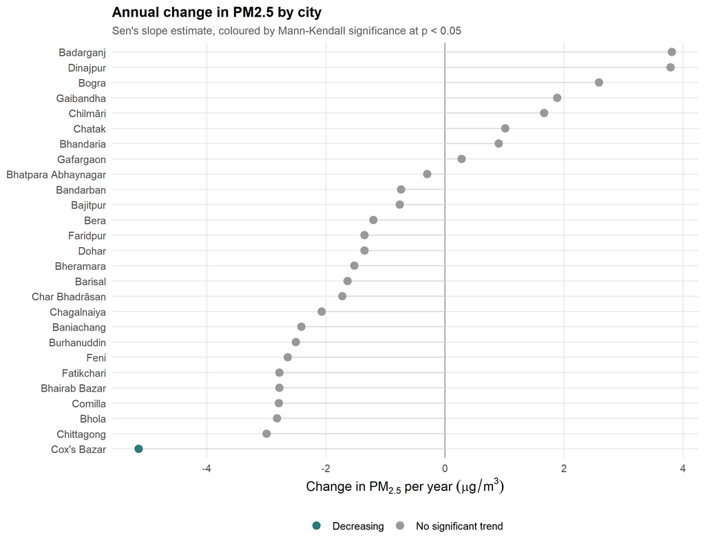

```r
ggplot(trend_results,
       aes(slope_per_year, fct_reorder(city, slope_per_year),
           colour = direction)) +
  geom_vline(xintercept = 0, colour = "grey60") +
  geom_segment(aes(xend = 0, yend = fct_reorder(city, slope_per_year)),
               colour = "grey85", linewidth = 0.5) +
  geom_point(size = 3) +
  scale_colour_manual(values = c("Increasing" = pal_bad,
                                 "Decreasing" = pal_main,
                                 "No significant trend" = "grey60"),
                      name = NULL) +
  labs(
    title = "Annual change in PM2.5 by city",
    subtitle = "Sen's slope estimate, coloured by Mann-Kendall significance at p < 0.05",
    x = expression(Change~"in"~PM[2.5]~per~year~(mu*g/m^3)), y = NULL
  )
```

A caution on interpretation. The record covers a little over three years and starts in August, so the series does not contain a whole number of seasonal cycles. Because the seasonal signal is very large, a trend estimated over this short a window is sensitive to exactly where the series begins and ends. These results should be read as a description of the study period rather than as evidence of a long-term change.

# 11 Year on year comparison

Only 2023 and 2024 are complete calendar years, so the comparison is limited to those two.

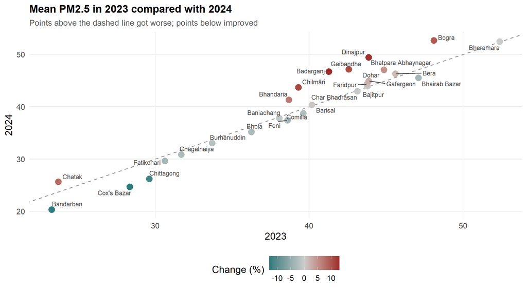

```r
yoy <- aq %>%
  filter(Year %in% c(2023, 2024)) %>%
  group_by(city, Year) %>%
  summarise(pm25 = mean(pm25, na.rm = TRUE), .groups = "drop") %>%
  pivot_wider(names_from = Year, values_from = pm25,
              names_prefix = "y") %>%
  mutate(change_pct = (y2024 - y2023) / y2023 * 100)

ggplot(yoy, aes(x = y2023, y = y2024)) +
  geom_abline(slope = 1, intercept = 0, linetype = "dashed", colour = "grey60") +
  geom_point(aes(colour = change_pct), size = 3.2) +
  ggrepel::geom_text_repel(aes(label = city), size = 2.8,
                           colour = "grey30", max.overlaps = 30) +
  scale_colour_gradient2(low = pal_main, mid = "grey80", high = pal_bad,
                         midpoint = 0, name = "Change (%)") +
  labs(
    title = "Mean PM2.5 in 2023 compared with 2024",
    subtitle = "Points above the dashed line got worse; points below improved",
    x = "2023", y = "2024"
  )
```

```r
yoy %>%
  mutate(across(c(y2023, y2024, change_pct), ~ round(.x, 1))) %>%
  arrange(desc(change_pct)) %>%
  kable(caption = "Change in mean PM2.5 from 2023 to 2024")
```

Change in mean PM2.5 from 2023 to 2024

| city | y2023 | y2024 | change_pct |
| --- | --- | --- | --- |
| Badarganj | 41.3 | 46.7 | 13.1 |
| Dinajpur | 43.9 | 49.4 | 12.6 |
| Chilmāri | 39.3 | 43.7 | 11.1 |
| Gaibandha | 42.6 | 47.1 | 10.7 |
| Bogra | 48.1 | 52.7 | 9.5 |
| Chatak | 23.7 | 25.6 | 8.1 |
| Bhandaria | 38.7 | 41.3 | 6.8 |
| Bhatpara Abhaynagar | 44.9 | 47.0 | 4.8 |
| Gafargaon | 43.9 | 44.9 | 2.4 |
| Bera | 45.6 | 46.3 | 1.5 |
| Dohar | 43.8 | 44.3 | 1.3 |
| Faridpur | 43.8 | 44.3 | 1.3 |
| Barisal | 40.2 | 40.3 | 0.4 |
| Bajitpur | 43.8 | 43.9 | 0.3 |
| Bheramara | 52.4 | 52.4 | 0.1 |
| Char Bhadrāsan | 43.1 | 43.0 | -0.4 |
| Baniachang | 38.1 | 37.8 | -0.7 |
| Burhanuddin | 33.7 | 33.1 | -2.0 |
| Comilla | 39.6 | 38.7 | -2.3 |
| Chagalnaiya | 31.7 | 30.9 | -2.7 |
| Bhola | 36.3 | 35.2 | -3.0 |
| Feni | 38.6 | 37.4 | -3.1 |
| Bhairab Bazar | 47.1 | 45.5 | -3.4 |
| Fatikchari | 30.6 | 29.6 | -3.4 |
| Chittagong | 29.6 | 26.2 | -11.5 |
| Bandarban | 23.3 | 20.3 | -12.7 |
| Cox’s Bazar | 28.4 | 24.7 | -12.9 |

# 12 Key findings

**Pollution levels are far above health guidelines.** Every one of the 27 cities exceeds the WHO annual PM2.5 guideline of 5 micrograms per cubic metre by a large margin, and the daily guideline of 15 is breached on the majority of days almost everywhere.

**There is a clear geographic gradient.** Northern and central cities such as Bheramara, Bogra and Dinajpur carry the highest burden. Coastal and hill cities in the south-east, including Bandarban, Chittagong and Cox’s Bazar, are markedly cleaner. Local sources and terrain both appear to matter.

**Season dominates everything else.** The winter to monsoon difference is larger than the difference between the most and least polluted city. Rain removal and better atmospheric mixing during the monsoon explain most of this.

**Trends over this record are weak and should be treated with care.** The series is just over three years long and does not start at a year boundary, which limits what can be said about long-term direction.

# 13 Limitations

1. The dataset covers 27 cities, not the full national network, so results should not be read as a national average.
2. The record starts in August 2022 and ends in November 2025, leaving two incomplete calendar years.
3. Carbon dioxide was dropped because roughly two thirds of the values are missing.
4. Hourly values are used as reported. No cross-checking against ground reference monitors was possible.
5. Correlation between pollutants indicates shared sources but does not establish any causal link.

# 14 Suggested next steps

- Link these concentrations to health outcome data to estimate the disease burden attributable to air pollution.
- Add meteorological covariates such as temperature, wind speed and boundary layer height to separate emission changes from weather-driven variability.
- Apply source apportionment methods to the PM2.5 to PM10 ratio and the trace gas profile to identify dominant emission sectors.
- Extend the analysis with distributed lag models once a health outcome series is available, since pollution effects on health are both delayed and non-linear.